# EPID600 FINAL PROJECT, SEDENTARY BEHAVIOR AND 30-YEAR FULL CVD RISK

All 9 independnet variables emerged significant in the RF model.

```r
#Logistic regression
top.glm <- glm(CVD_RISK_C~TV_HRS+DRIVE_HRS+ALCOHOL_INTAKE_C+SLEEP_C+CHRONO_C, data=data2, family=binomial(logit))
summary(top.glm)
```

```
##
## Call:
## glm(formula = CVD_RISK_C ~ TV_HRS + DRIVE_HRS + ALCOHOL_INTAKE_C +
##     SLEEP_C + CHRONO_C, family = binomial(logit), data = data2)
##
## Deviance Residuals:
##     Min       1Q   Median       3Q      Max
## -3.7580  -1.1923   0.7757   1.0453   1.6165
##
## Coefficients:
##                                             Estimate Std. Error z value
## (Intercept)                                 0.039523   0.014000   2.823
## TV_HRS                                      0.313398   0.002627 119.282
## DRIVE_HRS                                   0.048947   0.002979  16.433
## ALCOHOL_INTAKE_CThree or four times a week -0.399125   0.011088 -35.997
## ALCOHOL_INTAKE_COnce or twice a week       -0.560308   0.010943 -51.200
## ALCOHOL_INTAKE_COne to three times a month -0.681276   0.013800 -49.368
## ALCOHOL_INTAKE_CSpecial occasions only     -0.497508   0.014061 -35.383
## ALCOHOL_INTAKE_CNever                      -0.380685   0.016360 -23.269
## SLEEP_CLong                                 0.187067   0.016308  11.471
## SLEEP_CAdequate                            -0.111137   0.008865 -12.537
## CHRONO_CMore morning than evening          -0.119944   0.009431 -12.718
## CHRONO_CMore evening than morning          -0.237841   0.009997 -23.792
## CHRONO_CDefinitely evening                 -0.234457   0.014480 -16.192
##                                            Pr(>|z|)
## (Intercept)                                 0.00476 **
## TV_HRS                                      < 2e-16 ***
## DRIVE_HRS                                   < 2e-16 ***
## ALCOHOL_INTAKE_CThree or four times a week  < 2e-16 ***
## ALCOHOL_INTAKE_COnce or twice a week        < 2e-16 ***
## ALCOHOL_INTAKE_COne to three times a month  < 2e-16 ***
## ALCOHOL_INTAKE_CSpecial occasions only      < 2e-16 ***
## ALCOHOL_INTAKE_CNever                       < 2e-16 ***
## SLEEP_CLong                                 < 2e-16 ***
## SLEEP_CAdequate                             < 2e-16 ***
## CHRONO_CMore morning than evening           < 2e-16 ***
## CHRONO_CMore evening than morning           < 2e-16 ***
## CHRONO_CDefinitely evening                  < 2e-16 ***
## ---
## Signif. codes:  0 '***' 0.001 '**' 0.01 '*' 0.05 '.' 0.1 ' ' 1
##
## (Dispersion parameter for binomial family taken to be 1)
##
##     Null deviance: 437594  on 320888  degrees of freedom
## Residual deviance: 417361  on 320876  degrees of freedom
## AIC: 417387
##
## Number of Fisher Scoring iterations: 4
```

```r
glm.top.pred <- predict(top.glm, data2, type="response")


#10-fold cross-validation
N = nrow(data2)
K = 10
set.seed(1234)
s = sample(1:K, size=N, replace=T)
pred_outputs.glm <- vector(mode="numeric", length=N)
obs_outputs <- vector(mode="numeric", length=N)
offset <- 0
for(i in 1:K){
    train <- filter(data2, s != i)
    test <- filter(data2, s == i)
    obs_outputs[1:length(s[s==i]) + offset] <- test$CVD_RISK_C
    #GLM train/test
    glm <- glm(CVD_RISK_C~TV_HRS+DRIVE_HRS+ALCOHOL_INTAKE_C+SLEEP_C+CHRONO_C, data=train, family=binomial(logit))
    glm.pred.curr <- predict(glm, test, type="response")
    pred_outputs.glm[1:length(s[s==i]) + offset] <- glm.pred.curr


    offset <- offset + length(s[s==i])
}

#ROC Curves
plot.roc(data2$CVD_RISK_C, glm.top.pred, ci=TRUE, main="Using Top-Ranking Variables")
```

```
##
## Call:
## plot.roc.default(x = data2$CVD_RISK_C, predictor = glm.top.pred,     ci = TRUE, main = "Using Top-Ranking Variables")
##
## Data: glm.top.pred in 136369 controls (data2$CVD_RISK_C Low) < 184520 cases (data2$CVD_RISK_C High).
## Area under the curve: 0.6467
## 95% CI: 0.6447-0.6486 (DeLong)
```

```r
plot.roc(obs_outputs, pred_outputs.glm, ci=TRUE, col="darkblue", add=TRUE)
```

```
##
## Call:
## plot.roc.default(x = obs_outputs, predictor = pred_outputs.glm,     ci = TRUE, col = "darkblue", add = TRUE)
##
## Data: pred_outputs.glm in 136369 controls (obs_outputs 1) < 184520 cases (obs_outputs 2).
## Area under the curve: 0.6466
## 95% CI: 0.6447-0.6485 (DeLong)
```

```r
plot.roc(data2$CVD_RISK_C, rf.pred[, 2], ci=TRUE, col="darkgreen", add=TRUE)
```

```
##
## Call:
## plot.roc.default(x = data2$CVD_RISK_C, predictor = rf.pred[,     2], ci = TRUE, col = "darkgreen", add = TRUE)
##
## Data: rf.pred[, 2] in 136369 controls (data2$CVD_RISK_C Low) < 184520 cases (data2$CVD_RISK_C High).
## Area under the curve: 0.8975
## 95% CI: 0.8964-0.8986 (DeLong)
```

```r
plot.roc(obs_outputs, pred_outputs.rf, ci=TRUE, col="red", add=TRUE)
```

```
##
## Call:
## plot.roc.default(x = obs_outputs, predictor = pred_outputs.rf,     ci = TRUE, col = "red", add = TRUE)
##
## Data: pred_outputs.rf in 136369 controls (obs_outputs 1) < 184520 cases (obs_outputs 2).
## Area under the curve: 0.6727
## 95% CI: 0.6709-0.6746 (DeLong)
```

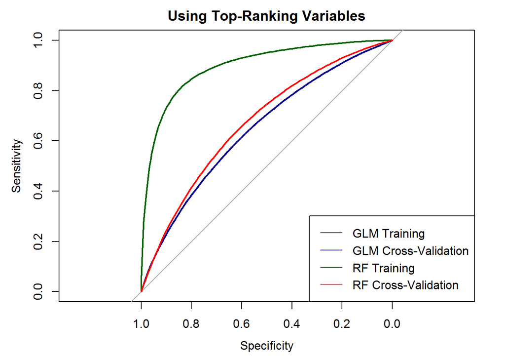

```r
legend("bottomright", legend=c("GLM Training", "GLM Cross-Validation", "RF Training", "RF Cross-Validation"), col=c("black", "darkblue", "darkgreen", "red"), lwd=1)
```

#### Odds ratios for logistic models

```r
# odds ratios for the full logistic model
exp(cbind(OR = coef(full.glm), confint(full.glm)))
```

```
##                                                   OR     2.5 %    97.5 %
## (Intercept)                                1.1607735 1.1152083 1.2082070
## TV_HRS                                     1.3780230 1.3708113 1.3852859
## COMP_HRS                                   1.0140769 1.0086324 1.0195563
## DRIVE_HRS                                  1.0462614 1.0401516 1.0524201
## PHYSICAL_ACTIVITY_CYes                     1.0265886 1.0110513 1.0423621
## FRUITVEG_RECOMMEND_MET_CYes                1.0416693 1.0246284 1.0590000
## ALCOHOL_INTAKE_CThree or four times a week 0.6736081 0.6591045 0.6884236
## ALCOHOL_INTAKE_COnce or twice a week       0.5769109 0.5646106 0.5894708
## ALCOHOL_INTAKE_COne to three times a month 0.5151964 0.5013557 0.5294143
## ALCOHOL_INTAKE_CSpecial occasions only     0.6227539 0.6056250 0.6403678
## ALCOHOL_INTAKE_CNever                      0.6950383 0.6729655 0.7178494
## SLEEP_CLong                                1.2151587 1.1769210 1.2547044
## SLEEP_CAdequate                            0.8946655 0.8792384 0.9103560
## CHRONO_CMore morning than evening          0.8883407 0.8720402 0.9049420
## CHRONO_CMore evening than morning          0.7906435 0.7752546 0.8063343
## CHRONO_CDefinitely evening                 0.7915240 0.7692857 0.8144129
## BODY_FAT_N                                 0.9942169 0.9933215 0.9951131
```

```r
# odds ratios for the logstic model with top ranking predictors
exp(cbind(OR = coef(top.glm), confint(top.glm)))
```

```
##                                                   OR     2.5 %    97.5 %
## (Intercept)                                1.0403147 1.0121600 1.0692602
## TV_HRS                                     1.3680658 1.3610453 1.3751353
## DRIVE_HRS                                  1.0501650 1.0440587 1.0563205
## ALCOHOL_INTAKE_CThree or four times a week 0.6709067 0.6564806 0.6856427
## ALCOHOL_INTAKE_COnce or twice a week       0.5710332 0.5589116 0.5834093
## ALCOHOL_INTAKE_COne to three times a month 0.5059709 0.4924668 0.5198403
## ALCOHOL_INTAKE_CSpecial occasions only     0.6080438 0.5915160 0.6250336
## ALCOHOL_INTAKE_CNever                      0.6833929 0.6618334 0.7056686
## SLEEP_CLong                                1.2057082 1.1678089 1.2449027
## SLEEP_CAdequate                            0.8948162 0.8793998 0.9104956
## CHRONO_CMore morning than evening          0.8869703 0.8707234 0.9035164
## CHRONO_CMore evening than morning          0.7883281 0.7730310 0.8039242
## CHRONO_CDefinitely evening                 0.7910005 0.7688713 0.8137745
```

In the full LR model, the odds of high CVD risk (versus low/model) increased by 38% for each additional hour of TV viewing, by 1% with each additional hour of computer use, by 5% with each additioanl hour of driving, by 3% for participants meeting PA recommendations, by 4% for participants meeting vegetable and fruit intake recommendations, by 22% for participants with long vs short sleep duration. Additionally, the odds of high CVD risk were greater among those with daily drinking, as compared to the other groups. The odds of high CVD risk also decreased by a factor of 0.105 for participants who slept adequately as compared to short, decreased by a factor of 0.112 for participants whose sleep timing preference was more morning than evening vs definitely morning, decreased by a factor of 0.209 for those with sleep timing preference more evening than morning vs definitely morning, decreased by a factor of 0.208 for those with a sleep timing preference as definitely evening vs definitely morning, and decreased by a factor of 0.006 for each percentage increase in body fat.